# Practical Machine Learning Course Project

Inaki Odriozola

14 January 2019

# Summary

This work aims at predicting if people are doing barble lifts correctly using data from accelerometers on the belt, forearm, arm, and dumbell. The dataset (Velloso et al. 2013) consists of measures on 6 individuals that were asked to do barble lifts correctly and incorrectly in five different ways. Part of the dataset (training set) will be used to train the models to be used to predict correctness of the lifts in the other part of the dataset (testing set).

# Load, explore and preprocess the data

## Loading the data and dividing into training and testing sets

```r
setwd("D:/APUNTEAK/Coursera/DATA_SCIENCE/8.Practical machine learning/Project")
```

Following code loads the training dataset to R and it further divides into a training dataset and testing dataset. Only the training data after the subdivision will be used to train the model, and, the testing data will be used just to check our final model and see the expected peformance of the model in the definitive testing set.

```r
dataset<-read.csv("pml-training.csv",row.names = 1,header=TRUE)
library(caret)
inTrain<-createDataPartition(y=dataset$classe,
                              p=0.75,list=FALSE)
training<-dataset[inTrain,]
testing<-dataset[-inTrain,]
```

## Exploring the dataset

What is the proportion of NAs in each variable?

```r
table(apply(apply(training,2,is.na),2,mean))
```

```
##
##                 0 0.977714363364588
##                92                67
```

There are 92 variables with no NAs and 67 variables with above 97% NAs. I will remove all variables that have NAs.

```r
training<-training[,apply(apply(training,2,is.na),2,mean)<0.95]
```

The name of the participant and the time variables will be removed as well, as they are not generalizable features to the general public. Hence, using them to train the model would lead to overfitting.

```r
training<-training[,-c(1:4)]
```

Variables without variation are likely poor predictors so they will be identified and removed.

```r
nvs<-nearZeroVar(training,saveMetrics = TRUE)
training<-training[,!nvs$nzv]
```

After all that filtering a dataset with 55 variables remains. Lets check collinearities between predictors. To to so, I’ll check the amount of principal components required to capture 80% of the variation in the dataset.

```r
summary(prcomp(training[,-c(length(training))]))$importance[,1:5]
```

```
##                              PC1       PC2       PC3       PC4       PC5
## Standard deviation     597.41919 534.25366 474.69992 381.87492 357.88551
## Proportion of Variance   0.25073   0.20052   0.15830   0.10245   0.08998
## Cumulative Proportion    0.25073   0.45125   0.60955   0.71200   0.80198
```

## Preprocess the data

```r
train_preProcessPCA<-preProcess(training[,-c(length(training))],method = "pca",thresh = .8)
```

# Build the predictive model

Random Forest algorithm will be used for prediction. The model will be fitted using k-fold cross-validation. First using the principal components.

```r
PC_extract_train<-predict(train_preProcessPCA,training)
library(randomForest)
```

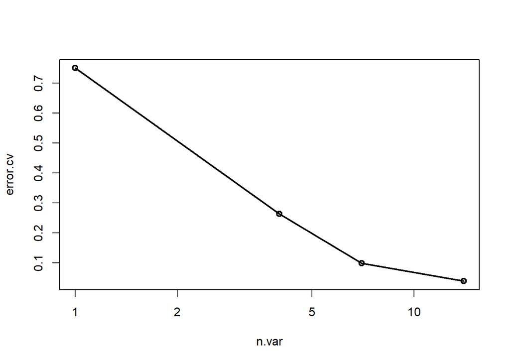

```r
RF_PCA<-rfcv(PC_extract_train[,-1],training$classe,cv.fold=5)
with(RF_PCA, plot(n.var, error.cv, log="x", type="o", lwd=2))
```

Since the cross-validation error is low with just 14 components, the model based on PCA will be used as final model. Lets fit it.

```r
modelFit_PCA_Train<-train(classe~.,method="rf",data=PC_extract_train,prox=TRUE)
```

# Expected out of the sample error

Expected out of the sample error will be measured by applying our model to the testing set we divided in the beginning. This is an approximation to the model performance in the final QUIZ testing set.

```r
PC_extract_test<-predict(train_preProcessPCA,testing)
confusionMatrix(testing$classe,predict(modelFit_PCA_Train,PC_extract_test))
```

```
## Confusion Matrix and Statistics
##
##           Reference
## Prediction    A    B    C    D    E
##          A 1371    5   12    6    1
##          B   12  921   15    0    1
##          C    3    6  837    9    0
##          D    2    6   27  766    3
##          E    3    5    5    1  887
##
## Overall Statistics
##
##                Accuracy : 0.9751
##                  95% CI : (0.9704, 0.9793)
##     No Information Rate : 0.2836
##     P-Value [Acc > NIR] : < 2.2e-16
##
##                   Kappa : 0.9685
##  Mcnemar's Test P-Value : 2.745e-05
##
## Statistics by Class:
##
##                      Class: A Class: B Class: C Class: D Class: E
## Sensitivity            0.9856   0.9767   0.9342   0.9795   0.9944
## Specificity            0.9932   0.9929   0.9955   0.9908   0.9965
## Pos Pred Value         0.9828   0.9705   0.9789   0.9527   0.9845
## Neg Pred Value         0.9943   0.9944   0.9854   0.9961   0.9988
## Prevalence             0.2836   0.1923   0.1827   0.1595   0.1819
## Detection Rate         0.2796   0.1878   0.1707   0.1562   0.1809
## Detection Prevalence   0.2845   0.1935   0.1743   0.1639   0.1837
## Balanced Accuracy      0.9894   0.9848   0.9648   0.9852   0.9955
```

Above, the expected accuracy and error values of my model.

# Bibliography

Velloso, E.; Bulling, A.; Gellersen, H.; Ugulino, W.; Fuks, H. Qualitative Activity Recognition of Weight Lifting Exercises. Proceedings of 4th International Conference in Cooperation with SIGCHI (Augmented Human ’13) . Stuttgart, Germany: ACM SIGCHI, 2013.